Optimizing Bike Routes Shane Hylton 2022-12-09

# Introduction

I often take the same route every day that I ride my bike. This is for two reasons. First, I am perfectly content doing the same thing over and over again. I am a habitual person, sometimes to a fault. Second, I have extremely limited time, and I know exactly how long this route takes, so I can know exactly what time I will be home, which makes it easier for me to follow a rigid schedule. The route is 10.00 miles long, sometimes I’ll travel 10.02 miles, but it is never below 10 miles. I also thought it would be a very useful exercise to export the data from multiple bike rides to analyze and plot in R, and having the identical route would make it easier for me to detect patterns.

# Problems with Export

I wear an Apple Watch when I ride my bike, and it is really good for collecting data to monitor within the Apple Health app only. Apple made some mistakes in the latest iOS, which has made the Health Data impossible to use immediately upon export. It requires that the file is patched manually prior to loading the .xml file in R. I attempted to patch the latest export several times this week, with no success. [iOS 16 Apple Health Data Export Patch](https://discussions.apple.com/thread/254202523?answerId=257895667022#257895667022)

As of today, I am still having issues loading the .xml file into R, even after patching the export file using the fix provided by community user etresoft. I also never exported my Health data prior to downloading iOS 16, so I will need to do further research to be able to export and use the Apple Health Data.

# Goals

I would ultimately like to be able to predict the time it will take me to finish the ten mile ride based on inputs like temperature, cloud cover, tire pressure, and time of day. Until I am able to actually load the data, I will be limited to setting goals and brainstorming ways to use the data. I’d also love to take the data from my bike rides and look at the fastest and slowest sections of the ride to see if there are spots that I should replace with other roads to make the route even more efficient. Until I am able to resolve the issues with reading the exported .xml files, I will need to be satisfied with the built in graphs Apple provides.

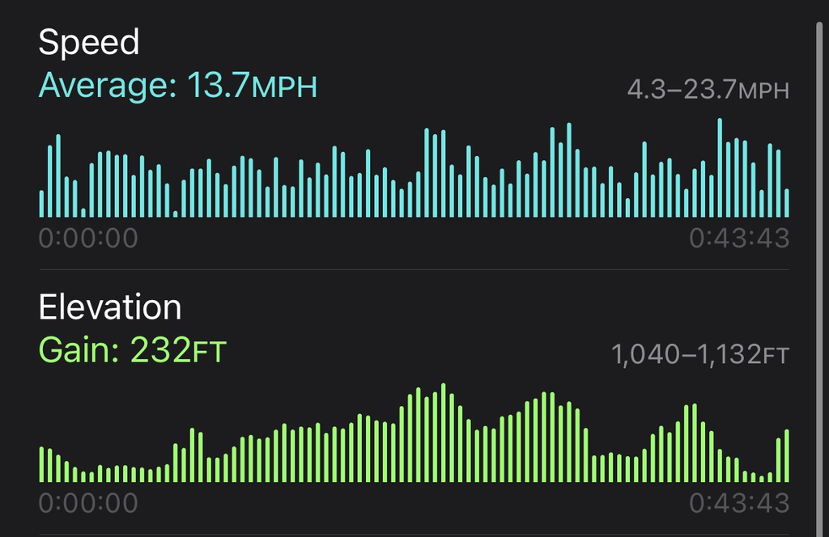

Speed and Elevation Gain

From these figures, it is interesting to note that my top speeds were often right at the peak elevation, or just after the peak. I would expect my top speeds to be in the troughs of the elevation plot, but that is not always the case with these two figures.